# R Ready to Map Presentation Unit 3

Dorris Scott  
11/07/2018

### Unit Objectives

- To have a basic understanding R Markdown framework
- To learn how to create a simple R Markdown document.
- To learn how to create an R Markdown presentation.

### First Things First!

Install the rmarkdown package and load it.

```r
install.packages("rmarkdown")
library(rmarkdown)
```

If you are getting error messages about packages missing then:

```r
install.packages("rmarkdown", dependencies = TRUE)
library(rmarkdown)
```

### Creating an R Markdown Document

File -> New File - R Markdown

- Click on Document.
- Add a Title and Author.
- Leave the Default Output as it is.

### Creating an R Markdown Document

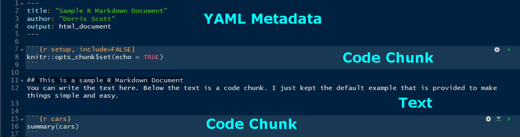

### Publishing an R Markdown Document

[figure not shown]

### Publishing an R Markdown Document

[figure not shown]

### Creating an R Markdown Presentation

File -> New File - R Markdown

- Click on Presentation.
- Add a Title and Author.
- Leave the Default Output as it is.

### Creating an R Markdown Presentation

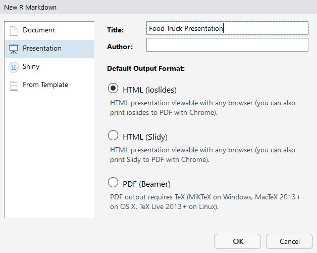

### Creating an R Markdown Presentation

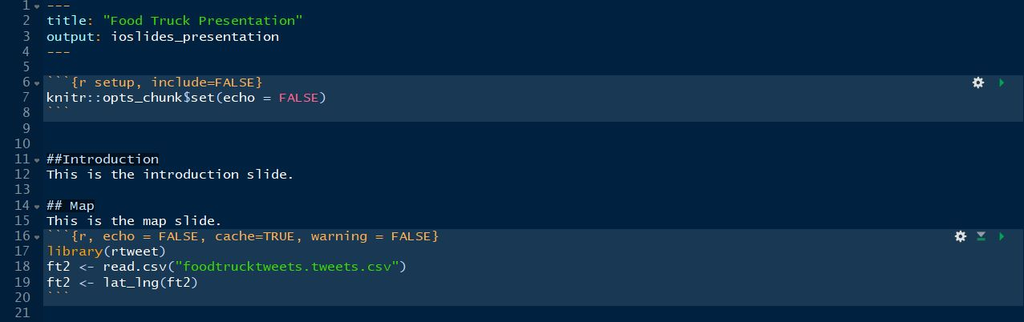

### Publishing an R Markdown Presentation

[figure not shown]

### Publishing an R Markdown Presentation

[figure not shown]

### Group Project: Exploring Fall Trends

The Three Groups

1. Fall Activities
2. UGA Football
3. Sports Trends

### Group Project: Exploring Fall Trends

Group Project Requirements

- Collecting tweets using either the stream_tweets or search_tweets function. Make sure to justify why you use one over the other.
- Creating an R Markdown document which includes these elements: leaflet map, plot, and at least five linked pictures. One of these pictures should be a wordcloud which includes most commonly occuring words. You only need to do this for at least 100 tweets! You can use this [website](https://www.jasondavies.com/wordcloud/) in order to make your WordCloud or you can choose whatever website you want!

### Group Project: Exploring Fall Trends

Your R Markdown document should have these sections:

- Leaflet Map. **10 points**
- Plot showing frequency of tweets over a time period using the ts_plot package. **6 points**
- How many tweets did you collect? Give the time period in which you collected tweets. **10 points**
- Issues encountered while collecting tweets. **10 points**

### Group Project: Exploring Fall Trends

You will also be graded on:

- Creating an R Markdown Presentation which includes the major elements of the project. **10 points**
- Presentation flow(making sure the presentation is cohesive and all members taking a part). **10 points**

### Total Points: 100